# Data Storytelling Project: Premiere Movie Analytics

Ramya Pinninti

2026-06-02

```r
library(naniar)
```

# 1 Introduction and Motivation

Know Your Data and Practical Questions

## 1.1 Background Story and Data Generation Process

This data set features movie data scraped from IMDB (the Internet Movie Database) and published on Kaggle.com. The population consists of real-world, historical observations of different movie premieres, tracking key metrics such as gross revenue, budget, runtime, and average user rating. A total of 634 observations was obtained.

**Data Dictionary**

Population: a set of 634 Hollywood feature films from recent decades.

```r
# Create an interactive data dictionary
data_dictionary <- tribble(
  ~Variable_Name,    ~Description,                                                        ~Variable_Type,
  "MovieID",          "Observation number of feature film",       "Numeric",
  "Title",          "Title of the film",  "Categorical",
  "MPAA_Rating",    "Maturity rating/suitability for young audiences",  "Categorical",
  "Budget",         "Total budget",    "Numeric",
  "Gross",          "Gross revenue",  "Numeric",
  "Release_Date",    "Film release date",  "Categorical",
  "Genre",          "Genre of film",  "Categorical",
  "Runtime",        "Film duration in minutes",  "Numeric",
  "Rating",          "IMDB rating",  "Numeric",
  "Rating_Count",   "Number of votes on IMDb",  "Numeric",
)

datatable(
  data_dictionary,
  caption = "Table 1: Variable definitions and types for the analysis dataset",
  rownames = FALSE,
  options = list(pageLength = 10, dom = 'tip')
)
```

| Variable_Name | Description | Variable_Type |
| --- | --- | --- |
| MovieID | Observation number of feature film | Numeric |
| Title | Title of the film | Categorical |
| MPAA_Rating | Maturity rating/suitability for young audiences | Categorical |
| Budget | Total budget | Numeric |
| Gross | Gross revenue | Numeric |
| Release_Date | Film release date | Categorical |
| Genre | Genre of film | Categorical |
| Runtime | Film duration in minutes | Numeric |
| Rating | IMDB rating | Numeric |
| Rating_Count | Number of votes on IMDb | Numeric |

```r
df <- read.csv("C:/Users/pinnints/Desktop/moviesdata.csv")
df <- df[rowSums(is.na(df) | df == "") != ncol(df), ]
```

## 1.2 Business Questions and Hypotheses

The purpose of collecting this dataset was to answer the following practical business questions:

**Business Question 1**: What is the relationship between the total budget and audience rating of a movie on IMDb and movie gross revenue?

**Business Question 2**: Which film genres produce the highest gross revenue?

**Business Question 3**: Which film genres produce the highest IMDb scores?

Hypotheses derived from domain knowledge:

**H1**: Films with a higher budget, on average, will have a higher gross revenue.

**H2**: There is a positive, linear relationship between IMDb rating and the gross revenue.

**H3**: Gross revenue differs significantly between genre groups.

These hypotheses will guide our exploratory visual analysis and help us focus the narrative.

## 1.3 Univariate Distribution Analysis

### 1.3.1 Distributions of Key Numeric Variables

Understanding the distributional shape of the numeric variables—Budget, Gross Revenue, Runtime, and IMDb Rating—is essential for detecting skewness, multimodality, and extreme outliers that could distort summary statistics and subsequent models.

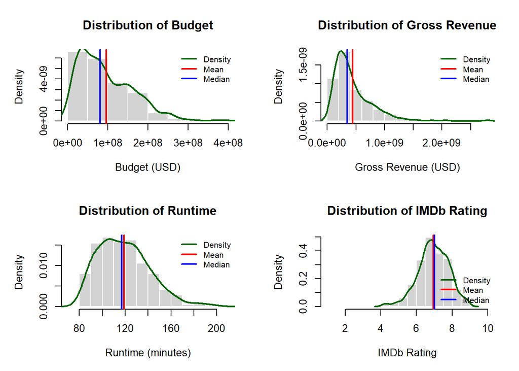

```r
par(mfrow = c(2, 2), mar = c(5, 5, 4, 2))

# --- Budget ---
hist(df$Budget,
     main = "Distribution of Budget",
     xlab = "Budget (USD)",
     col = "lightgray", border = "white", freq = FALSE)
lines(density(df$Budget, na.rm = TRUE), col = "darkgreen", lwd = 2)
abline(v = mean(df$Budget, na.rm = TRUE), col = "red", lwd = 2)
abline(v = median(df$Budget, na.rm = TRUE), col = "blue", lwd = 2)
legend("topright", legend = c("Density", "Mean", "Median"),
       col = c("darkgreen", "red", "blue"), lwd = 2, bty = "n", cex = 0.8)

# --- Gross Revenue ---
hist(df$Gross,
     main = "Distribution of Gross Revenue",
     xlab = "Gross Revenue (USD)",
     col = "lightgray", border = "white", freq = FALSE)
lines(density(df$Gross, na.rm = TRUE), col = "darkgreen", lwd = 2)
abline(v = mean(df$Gross, na.rm = TRUE), col = "red", lwd = 2)
abline(v = median(df$Gross, na.rm = TRUE), col = "blue", lwd = 2)
legend("topright", legend = c("Density", "Mean", "Median"),
       col = c("darkgreen", "red", "blue"), lwd = 2, bty = "n", cex = 0.8)

# --- Runtime ---
hist(df$Runtime,
     main = "Distribution of Runtime",
     xlab = "Runtime (minutes)",
     col = "lightgray", border = "white", freq = FALSE)
lines(density(df$Runtime, na.rm = TRUE), col = "darkgreen", lwd = 2)
abline(v = mean(df$Runtime, na.rm = TRUE), col = "red", lwd = 2)
abline(v = median(df$Runtime, na.rm = TRUE), col = "blue", lwd = 2)
legend("topright", legend = c("Density", "Mean", "Median"),
       col = c("darkgreen", "red", "blue"), lwd = 2, bty = "n", cex = 0.8)

# --- IMDb Rating ---
hist(df$Rating,
     main = "Distribution of IMDb Rating",
     xlab = "IMDb Rating",
     col = "lightgray", border = "white", freq = FALSE,
     breaks = seq(1, 10, by = 0.5))
lines(density(df$Rating, na.rm = TRUE, adjust = 0.7),
      col = "darkgreen", lwd = 2)
abline(v = mean(df$Rating, na.rm = TRUE), col = "red", lwd = 2)
abline(v = median(df$Rating, na.rm = TRUE), col = "blue", lwd = 2)
legend("bottomright", legend = c("Density", "Mean", "Median"),
       col = c("darkgreen", "red", "blue"), lwd = 2, bty = "n", cex = 0.8)
```

[figure not shown]

```r
agg_genre <- aggregate(cbind(Budget, Gross) ~ Genre, data = df,
                       FUN = mean, na.rm = TRUE)


agg_genre <- agg_genre[order(agg_genre$Gross, decreasing = TRUE), ]
topN <- 5
agg_top <- head(agg_genre, topN)


plot_mat <- as.matrix(agg_top[, c("Budget", "Gross")]) / 1e6
rownames(plot_mat) <- agg_top$Genre


par(mar = c(6, 14,4,2))

barplot(t(plot_mat),
        main  = "Top 10 Genres by Gross: Budget vs Gross",
        xlab  = "Average USD (in Millions)",
        ylab  = "",
        col   = c("#E50914", "#221F1F"),
        legend.text = c("Budget", "Gross"),
        args.legend = list(x = "topright", bty = "n", cex = 0.8),
        beside = TRUE,
        horiz  = TRUE,
        names.arg = rownames(plot_mat),
        las = 1,
        cex.names = 0.9,
        xlim = c(0, max(plot_mat) * 1.2))

box()
mtext("Genre", side = 2, line = 6, cex = 1.1)
```

[figure not shown]

```r
par(mar = c(12, 6, 4, 2))
agg <- aggregate(Gross ~ Genre, df, mean, na.rm = TRUE)
agg <- agg[order(agg$Gross, decreasing = TRUE), ]
top10 <- head(agg, 10)

par(mar = c(6, 14, 4, 2))
barplot(top10$Gross / 1e6,
        names.arg = top10$Genre,
        horiz = TRUE,
        las = 1,
        col = "#E50914",
        main = "Top 5 Genres by Average Gross Revenue",
        xlab = "Gross Revenue (Millions USD)")
```

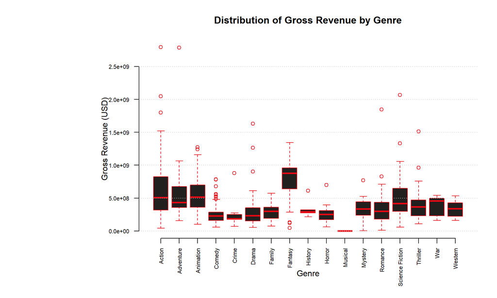

```r
boxplot(Gross ~ Genre, data = df,
        main = "Distribution of Gross Revenue by Genre",
        ylab = "Gross Revenue (USD)",
        las = 2,              #
        cex.axis = 0.7,
        col = "#221F1F",
        border = "#E50914",
        frame.plot = FALSE)


grid(nx = NA, ny = NULL, col = "gray80", lty = "dotted")
```

**Summary of Observations and Implications**: Budget and Gross Revenue both exhibit pronounced right‑skew with long upper tails. Most films cluster at modest financial levels, while a small number of exceptionally high‑budget or high‑grossing titles extend far to the right. The mean lies noticeably to the right of the median, confirming the influence of outliers. This pattern is typical of film industry data, where blockbuster productions and global hits dominate the upper extremes.

Runtime shows a near‑normal distribution centered around 110–120 minutes, with the mean and median nearly overlapping. The density curve is smooth and symmetric, indicating that most films conform to standard feature‑length expectations. Only a few unusually short or long films deviate from this central tendency.

IMDb Rating displays a compact, slightly left‑skewed distribution, concentrated between 6 and 8. The mean and median are nearly identical, suggesting that audience sentiment is stable and balanced, with few extreme ratings. This contrasts with the financial variables.

These distributional characteristics carry direct implications for modeling. The heavy right‑skew in Budget and Gross warrants log‑transformations or Box‑Cox adjustments when using linear models to stabilize variance and reduce leverage from outliers. Runtime and Rating, being approximately symmetric, can be used directly as predictors.

The horizontal bar chart of Top Genres by Average Revenue reveals that Action and Fantasy dominate financially, each averaging above 600 million USD. The comparative chart of Budget vs Gross shows that high‑grossing categories also require substantial investment.

### 1.3.2 Distributions of Categorical Variables

Categorical variables define the segments and groups that underpin our business questions. A simple frequency breakdown not only reveals the balance — or imbalance — among classes but also surfaces any categories with insufficient data to support reliable inference. Ordered bar charts provide an immediate visual ranking of the most common categories.

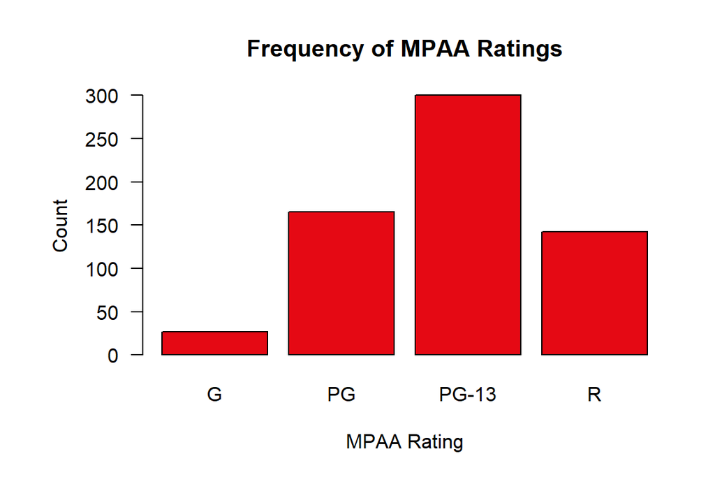

```r
par(mfrow = c(1, 1))
par(mar = c(5, 6, 4, 2))

barplot(table(df$MPAA_Rating),
        main = "Frequency of MPAA Ratings",
        col = "#E50914",
        las = 1,
        cex.names = 1,
        xlab = "MPAA Rating",
        ylab = "Count")
```

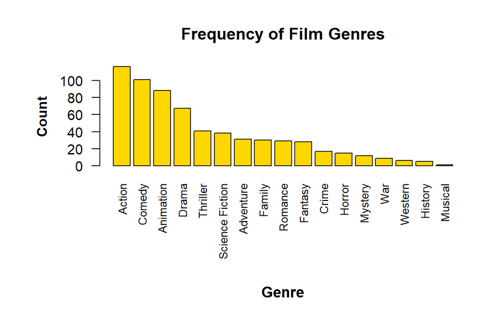

```r
par(mar = c(10, 6, 4, 2), font.lab = 1, family = "sans")

barplot(sort(table(df$Genre), decreasing = TRUE),
        main      = "Frequency of Film Genres",
        col       = "#FFD700",
        border    = "#221F1F",
        las       = 2,
        cex.names = 0.8,
        ylab      = "Count",
        font.lab  = 2)

mtext("Genre", side = 1, line = 7, cex = 1.1, font = 2, family = "sans")
```

**Summary of Observations and Implications**: An analysis of the key categorical variables Genre and MPAA Rating shows that the majority of observations fall into a few categories. The top four categories of Genre are Action, Comedy, Animation, and Drama. Notably, genres such as Western, History and Musical appear rarely in the data set. The distribution of genres and the significant decline towards niche genres indicates a production bias towards films that are commercially successful. Subsequent analyses should account for the difference in sample size across genres. For modeling purposes, rare categories can be collapsed into an “other” group.

The majority of films from the data set have an MPAA Rating of PG-13, followed by PG and R. G-rated films are less common and the data suggests an industry trend favoring PG-13 movies, which may attract both teens and adults.

## 1.4 Relationships Between Variables

### 1.4.1 Correlation and Trend Discovery

A scatterplot matrix provides a compact visual summary of pairwise interactions, allowing for an assessment of the strength of linear relationships between numeric variables. Non-linear patterns that simple correlation coefficients overlook can also be identified.

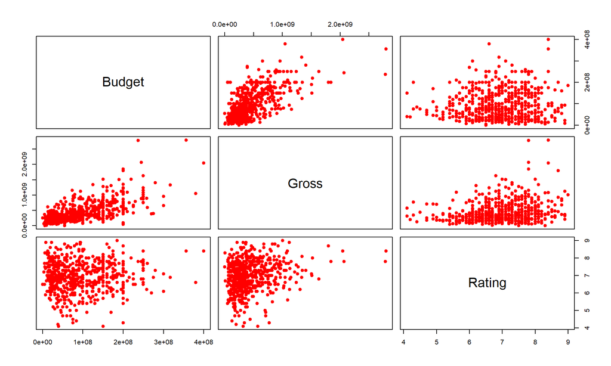

```r
pairs(df[, c("Budget", "Gross", "Rating")],
      col = "red", pch = 19)
```

```r
cor(df[, c("Budget", "Gross", "Rating")], use = "complete.obs")
```

```
##            Budget     Gross     Rating
## Budget 1.00000000 0.6875896 0.04917761
## Gross  0.68758964 1.0000000 0.23633092
## Rating 0.04917761 0.2363309 1.00000000
```

**Summary of Observations and Implications**: The scatterplot matrix shows a positive relationship between budget and gross revenue, indicating that films with larger production budgets tend to bring in greater box office returns. This is the only strong linear association in the matrix, suggesting that budget is a meaningful predictor of a film’s financial success.

### 1.4.2 Comparing Distributions Across Groups

Boxplots provide a concise way to compare the spread, central tendency, and variability of numeric outcomes across categorical groups. By visualizing gross revenue distributions for each genre, we can identify which categories consistently outperform others, which exhibit high variability, and whether any extreme outliers dominate the dataset. This comparison helps determine whether genre is a meaningful predictor of financial success.

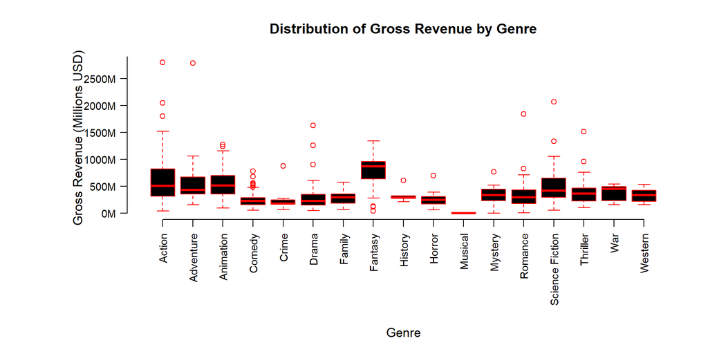

```r
par(mar = c(9.5, 9, 4, 2))

ticks <- pretty(df$Gross)


boxplot(Gross ~ Genre, data = df,
        main = "Distribution of Gross Revenue by Genre",
        ylab = "Gross Revenue (Millions USD)",
        xlab = "",
        las = 2,
        cex.axis = 0.9,
        cex.lab = 1.1,
        col = "black",
        border = "red",
        frame.plot = FALSE,
        yaxt = "n",
        mgp = c(6, 1, 0))


axis(2,
     at = ticks,
     labels = paste0(round(ticks / 1e6), "M"),
     las = 1,
     cex.axis = 0.9,
     mgp = c(3, 0.8, 0))


mtext("Genre", side = 1, line = 7.5, cex = 1.1)
```

**Summary of Observations and Implications**: The boxplot shows noticeable variation in gross revenue across genres. Action, Adventure, Animation and Fantasy have high medians, indicating strong typical performance. Musical, History, and Horror tend to have lower medians, suggesting more modest returns. Genres such as Action and Adventure have the highest outliers, showing that a few global hits skew the overall distribution in these categories.

### 1.4.3 Contingency and Association

When both variables are categorical, understanding the pattern of co-occurrence is key. A normalized grouped bar chart helps compare conditional proportions, revealing whether the distribution of one variable shifts meaningfully across the levels of the other. This is essential for identifying interaction effects that can be encoded in models or decision trees.

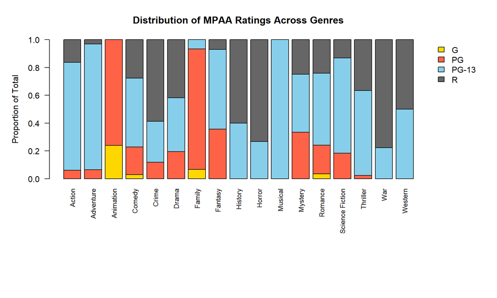

```r
tab <- table(df$Genre, df$MPAA_Rating)
prop_tab <- prop.table(tab, 1)


par(mar = c(12, 5, 4, 7))
par(xpd = TRUE)

bp <- barplot(t(prop_tab),
              beside = FALSE,
              col = c("gold", "tomato", "skyblue", "gray40"),
              ylim = c(0, 1),
              main = "Distribution of MPAA Ratings Across Genres",
              ylab = "Proportion of Total",
              las = 2,
              cex.names = 0.8)


usr <- par("usr")


legend(x = usr[2] + 0.2,
       y = 1,
       legend = c("G", "PG", "PG-13", "R"),
       fill   = c("gold", "tomato", "skyblue", "gray40"),
       bty    = "n",
       xjust  = 0)
```

**Summary of Observations and Implications**: The chart shows clear differences in MPAA rating composition across genres. Family and Animation films contain higher proportions of G and PG ratings, reflecting content aimed at younger or general audiences. In contrast, genres such as Action, Thriller, and Horror are dominated by PG‑13 and R ratings, indicating more mature themes and restricted audiences.

Mixed genres like Comedy span all rating categories, suggesting broader flexibility in content. These patterns demonstrate that genre and MPAA rating are not independent; certain genres are associated with specific rating profiles. For modeling purposes, this suggests including both variables or an interaction term may improve predictions of revenue. From a strategic perspective, the results suggest that marketing and distribution decisions should align with the typical rating profile of each genre rather than treating all genres uniformly.

# 2 Effective Visual Storytelling: From Insights to Action

The analyses conducted throughout this study questioned the economic and perceptual drivers of film performance. Each visualization contributed a piece of evidence that tells a story about how budget, genre, audience rating, and content classification interact to shape financial outcomes. In this concluding section, we translate those visual insights into actionable recommendations for decision‑makers in film production, marketing, and strategic planning.

## 2.1 How to Use Visual Insights to Support Business Decisions

The visual evidence we have gathered directly informs several high-priority business decisions:

**Decision on Production Budget Strategy**: The scatterplot matrix revealed a strong, positive relationship between Budget and Gross Revenue, with signs of diminishing returns at the upper end.

Recommendation: Allocate large budgets strategically to genres historically capable of generating blockbuster‑level returns (e.g., Action, Adventure, Fantasy). For genres with lower median revenue (Drama, Horror), adopt a controlled‑budget strategy to maximize ROI. This targeted budgeting approach reduces financial risk.

**Decision on Decision on Audience Targeting and Rating Strategy**: The contingency analysis demonstrated that MPAA Rating distributions vary sharply by genre (e.g., Family/Animation skew G–PG, Action/Thriller skew PG‑13–R). Recommendation:  
Align marketing campaigns and release strategies with the rating profiles typical of each genre. For example, PG‑13 Action films should emphasize teen‑adult appeal.

## 2.2 How to Use Visual Findings to Inform Subsequent Data Analysis and Modeling

The visual EDA provides a roadmap for the next phase of the data science lifecycle:

**Feature Engineering**: The Budget–Gross relationship shows curvature, suggesting the need for a log‑transformation.Genre and MPAA Rating exhibit non‑independence, supporting the inclusion of interaction terms or dummy‑encoded categorical features.

**Model Selection**: TThe presence of outliers in revenue and skewed distributions across genres suggests that tree‑based models (Random Forest, Gradient Boosting) or robust regression will outperform simple linear models.

The weak linear relationship between Rating and Gross indicates that Rating should not be treated as a linear predictor without transformation or binning.

**Hypothesis Validation**: The visual evidence provides preliminary support for H1 and H3.H1 will be formally tested using correlation and regression.

## 2.3 Dashboard and Real-Time Monitoring Implementation

If this project is intended for a production dashboard, here is the blueprint for implementation:

The layout of the dashboard should mirror the storytelling narrative we’ve constructed, organized in three logical tabs:

**Tab 1: “Market Overview”** Include univariate distributions of Budget, Gross, and Rating to monitor shifts in the film landscape. Automated alerts can flag unusual spikes in missing budget data or extreme outliers in revenue.

**Tab 2: “Genre & Audience Insights”** Embed interactive versions of the genre boxplots and the scatterplot matrix. Analysts can filter by year, studio, or rating to explore how genre performance evolves over time.

**ab 3: “Strategic Decision Tracker”** Display before‑and‑after metrics tied to the decisions above — such as ROI by genre, budget allocation efficiency, or rating‑specific audience engagement.